# PERFect: method validation for Bacterial Diversity in Neonatal Intensive Care Units (NICUs) data

Ekaterina Smirnova

Sat Mar 31 21:33:03 2018

These data (Knights et al., 2011) with with 30 samples and 1097 was collected to investigate the sources of bacteria found on surfaces and equipment in NICU. The data taxa was previously analyzed using sourcetracker software to identify the proportion of bacteria from each environment using published datasets from environments likely to be sources of indoor contaminants, namely human skin, oral cavities, feces and temperate soils. The sourcetracker results (see Table 1) reveal that in most NICU samples, the largest proportion of microbial communities come from the skin and unknown OTU samples, however this software does not specify which taxa are predicted in each environment.

|  | Gut | Oral | Skin | Soil | Unknown |
| --- | --- | --- | --- | --- | --- |
| NICU Button 1 | 0.0700 | 0.0046 | 0.2652 | 0.0005 | 0.6597 |
| NICU Button 2 | 0.0000 | 0.0008 | 0.4523 | 0.0015 | 0.5454 |
| NICU Button 3 | 0.0003 | 0.0005 | 0.2169 | 0.0009 | 0.7814 |
| NICU Button 4 | 0.0001 | 0.0008 | 0.0312 | 0.0001 | 0.9678 |
| NICU Counter 1 | 0.0287 | 0.0026 | 0.1126 | 0.0010 | 0.8551 |
| NICU Counter 2 | 0.0005 | 0.0035 | 0.0364 | 0.0005 | 0.9591 |
| NICU Counter 3 | 0.0013 | 0.0749 | 0.4797 | 0.0043 | 0.4398 |
| NICU Counter 4 | 0.0008 | 0.0045 | 0.0400 | 0.0008 | 0.9539 |
| NICU Handle 1 | 0.0001 | 0.0067 | 0.1167 | 0.0014 | 0.8751 |
| NICU Handle 2 | 0.0036 | 0.0107 | 0.2412 | 0.0010 | 0.7435 |
| NICU Handle 3 | 0.0013 | 0.0166 | 0.3529 | 0.0140 | 0.6153 |
| NICU Handle 4 | 0.0008 | 0.0102 | 0.2220 | 0.0018 | 0.7652 |
| NICU Handle 5 | 0.0043 | 0.0046 | 0.2067 | 0.0022 | 0.7822 |
| NICU Handle 6 | 0.0005 | 0.0043 | 0.0768 | 0.0003 | 0.9181 |
| NICU Handle 7 | 0.0005 | 0.0018 | 0.0391 | 0.0003 | 0.9583 |
| NICU Handle 8 | 0.0005 | 0.0364 | 0.3351 | 0.0020 | 0.6260 |
| NICU Handle 9 | 0.0001 | 0.0053 | 0.5806 | 0.0017 | 0.4123 |
| NICU Handle 10 | 0.0011 | 0.0031 | 0.2149 | 0.0017 | 0.7792 |
| NICU Handle 11 | 0.0008 | 0.0018 | 0.0468 | 0.0017 | 0.9489 |
| NICU Handle 12 | 0.0001 | 0.0144 | 0.0338 | 0.0007 | 0.9510 |
| NICU Incubator 1 | 0.0001 | 0.0011 | 0.0456 | 0.0002 | 0.9530 |
| NICU Incubator 2 | 0.0005 | 0.0022 | 0.0515 | 0.0014 | 0.9444 |
| NICU Keyboard 1 | 0.0002 | 0.0010 | 0.3131 | 0.0009 | 0.6848 |
| NICU Keyboard 2 | 0.0002 | 0.0135 | 0.4172 | 0.0019 | 0.5672 |
| NICU Keyboard 3 | 0.0003 | 0.0016 | 0.1123 | 0.0010 | 0.8848 |
| NICU Keyboard 4 | 0.0038 | 0.0114 | 0.5865 | 0.0030 | 0.3953 |
| NICU Plastic 1 | 0.0010 | 0.0014 | 0.1089 | 0.0011 | 0.8876 |
| NICU Plastic 2 | 0.0002 | 0.0254 | 0.1004 | 0.0018 | 0.8722 |
| NICU Screen 1 | 0.0001 | 0.0038 | 0.0636 | 0.0011 | 0.9314 |
| NICU Screen 2 | 0.0002 | 0.0099 | 0.0783 | 0.0010 | 0.9106 |

Dimension of the data set

```
## [1]   30 1097
```

# PERFect validation metrics

## Results

1. Simultaneous PERFect with skew-normal distribution and NP ordering.
2. Simultaneous PERFect with skew-normal distribution and p-values ordering.

The histogram of log differences in filtering loss for the simultaneous PERFect method shows that the method is generally robust to the choice of quantiles used to fit the Skew-Normal distribution.

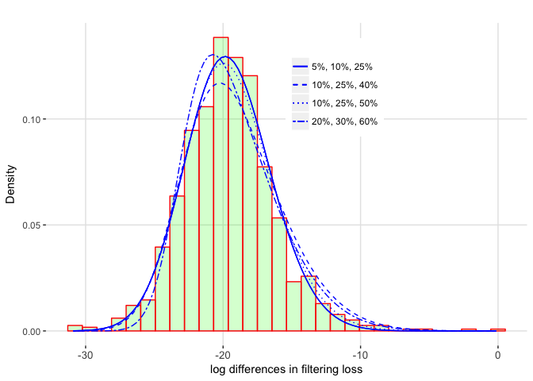

2. Permutation PERFect with skew-normal distribution NP ordering.

```
## Time difference of 44.1899 mins
```

```
## Time difference of 16.04777 mins
```

```
## Time difference of 15.59793 mins
```

```
## Time difference of 17.48589 mins
```

3. Permutation perfect with simultaneous p-values ordering from simultaneous PERFect with Skew Normal fit
4. Decontam package results

Negative controls or DNA concentrations data is not available as a part of publically available data distributed with sourcetracker package.

5. Traditional Filtering Rule 1
6. Traditional Filtering Rule 2

# Table of results comparison

1. Number of taxa present

|  | Total number of taxa | # of taxa preserved | Percentage of filtered taxa |
| --- | --- | --- | --- |
| PERFect_sim_a_0.15 | 1097 | 230 | 79.03 |
| PERFect_sim_b_0.15 | 1097 | 134 | 87.78 |
| PERFect_sim_c_0.15 | 1097 | 230 | 79.03 |
| PERFect_sim_d_0.15 | 1097 | 230 | 79.03 |
| PERFect_sim_a_0.10 | 1097 | 134 | 87.78 |
| PERFect_sim_b_0.10 | 1097 | 114 | 89.61 |
| PERFect_sim_c_0.10 | 1097 | 134 | 87.78 |
| PERFect_sim_d_0.10 | 1097 | 114 | 89.61 |
| PERFect_sim_a_0.05 | 1097 | 88 | 91.98 |
| PERFect_sim_b_0.05 | 1097 | 88 | 91.98 |
| PERFect_sim_c_0.05 | 1097 | 88 | 91.98 |
| PERFect_sim_d_0.05 | 1097 | 88 | 91.98 |
| PERFect_sim_a_pvals_0.15 | 1097 | 362 | 67.00 |
| PERFect_sim_b_pvals_0.15 | 1097 | 159 | 85.51 |
| PERFect_sim_c_pvals_0.15 | 1097 | 169 | 84.59 |
| PERFect_sim_d_pvals_0.15 | 1097 | 165 | 84.96 |
| PERFect_sim_a_pvals_0.10 | 1097 | 170 | 84.50 |
| PERFect_sim_b_pvals_0.10 | 1097 | 62 | 94.35 |
| PERFect_sim_c_pvals_0.10 | 1097 | 128 | 88.33 |
| PERFect_sim_d_pvals_0.10 | 1097 | 122 | 88.88 |
| PERFect_sim_a_pvals_0.05 | 1097 | 130 | 88.15 |
| PERFect_sim_b_pvals_0.05 | 1097 | 59 | 94.62 |
| PERFect_sim_c_pvals_0.05 | 1097 | 57 | 94.80 |
| PERFect_sim_d_pvals_0.05 | 1097 | 61 | 94.44 |
| PERFect_perm_np_a_0.15 | 1097 | 426 | 61.17 |
| PERFect_perm_np_b_0.15 | 1097 | 314 | 71.38 |
| PERFect_perm_np_c_0.15 | 1097 | 314 | 71.38 |
| PERFect_perm_np_d_0.15 | 1097 | 387 | 64.72 |
| PERFect_perm_np_a_0.10 | 1097 | 332 | 69.74 |
| PERFect_perm_np_b_0.10 | 1097 | 240 | 78.12 |
| PERFect_perm_np_c_0.10 | 1097 | 230 | 79.03 |
| PERFect_perm_np_d_0.10 | 1097 | 230 | 79.03 |
| PERFect_perm_np_a_0.05 | 1097 | 239 | 78.21 |
| PERFect_perm_np_b_0.05 | 1097 | 230 | 79.03 |
| PERFect_perm_np_c_0.05 | 1097 | 166 | 84.87 |
| PERFect_perm_np_d_0.05 | 1097 | 134 | 87.78 |
| PERFect_perm_pvals_a_0.15 | 1097 | 417 | 61.99 |
| PERFect_perm_pvals_b_0.15 | 1097 | 299 | 72.74 |
| PERFect_perm_pvals_c_0.15 | 1097 | 366 | 66.64 |
| PERFect_perm_pvals_d_0.15 | 1097 | 360 | 67.18 |
| PERFect_perm_pvals_a_0.10 | 1097 | 361 | 67.09 |
| PERFect_perm_pvals_b_0.10 | 1097 | 298 | 72.84 |
| PERFect_perm_pvals_c_0.10 | 1097 | 243 | 77.85 |
| PERFect_perm_pvals_d_0.10 | 1097 | 262 | 76.12 |
| PERFect_perm_pvals_a_0.05 | 1097 | 274 | 75.02 |
| PERFect_perm_pvals_b_0.05 | 1097 | 159 | 85.51 |
| PERFect_perm_pvals_c_0.05 | 1097 | 169 | 84.59 |
| PERFect_perm_pvals_d_0.05 | 1097 | 146 | 86.69 |
| Trad_R1 | 1097 | 331 | 69.83 |
| Trad_R2 | 1097 | 630 | 42.57 |

2. Running time for each method

| PERFect Simultaneous | PERFect Permutation | Traditional Rule 1 | Traditional Rule 2 |
| --- | --- | --- | --- |
| 2.4479 secs | 44.1899 mins | 0.026 secs | 0.0375 secs |

3. Proportion of taxa preserved in each environment

|  | Skin | Soil | Oral | Gut | Unknown | Skin and Oral | Skin and Gut | Skin and Soil | Gut and Soil | Skin, Oral and Gut | Skin, Oral Gut, Soil |
| --- | --- | --- | --- | --- | --- | --- | --- | --- | --- | --- | --- |
| total | 186 | 121 | 7 | 41 | 503 | 74 | 45 | 74 | 5 | 36 | 5 |
| PERFect_sim | 31 | 9 | 0 | 0 | 30 | 9 | 4 | 30 | 4 | 14 | 3 |
| PERFect_perm_np | 54 | 16 | 0 | 1 | 66 | 18 | 9 | 41 | 5 | 16 | 4 |
| PERFect_perm_pvals | 58 | 16 | 0 | 1 | 71 | 17 | 9 | 47 | 5 | 15 | 4 |
| Trad_R1 | 73 | 26 | 0 | 3 | 113 | 26 | 11 | 48 | 5 | 22 | 4 |
| Trad_R2 | 122 | 66 | 2 | 28 | 246 | 43 | 33 | 50 | 4 | 31 | 5 |